# Figures for Section 5

```r
library(REMLSimulationPaper)
```

```r
set.seed(1234)

pacman::p_load(
  tidyverse
)

pacman::p_load_gh(
  "dpavlyshyn/halfsibdesign" # Simulate and fit balanced half-sib designs
)
# Set a global theme for all figures in the document
theme_set(theme_bw())
```

# Figures 5 and 6: Nearly-null subspaces

In this section, we simulate half-sib designs with warious covariance structures for between-sires and between-dams covariance matrices. In all cases, the between-individuals covariance matrices will simply be identites.

The between-sires covariances $\Sigma_A$ are described in eq. (7)

```r
a_types <- list(
  identity = function(p, d) diag(c(rep(1, p - d), rep(0, d))),
  chispuared = function(p, d) diag(c(rchisp(p - d, df=5), rep(0, d))),
  heavytail = function(p, d) diag(c(abs(rcauchy(p - d, location=5)), rep(0, d)))
)

a_names <- c(
  identity   = "Identity",
  chisquared = "Chi-squared",
  heavytail  = "Heavy-tailed",
  spike      = "Spiked"
)
```

```r
b_types <- list(
  identity = function(p) diag(p),
  wishart = function(p) {
    X <- matrix(rnorm(p*p), nrow = p)
    X %*% t(X) / p
  },
  highrank = function(p) {
    P <- matrix(rnorm(p*p), nrow = p) %>%
      {. + t(.)} %>%
      eigen(symmetric=TRUE) %>%
      .$vectors
    D <- diag(rchisp(p, df=5))
    P %*% D %*% t(P)
  },
  highcorr = function(p) matrix(0.8, nrow=p, ncol=p) + 0.2 * diag(p)
)

b_names <- c(
  identity = "Identity",
  wishart  = "Wishart",
  highrank = "High-rank",
  highcorr = "High-corr"
)
```

We set those parameters specified in the paragraph beginning with *Remaining parameter settings*:

```r
p <- 50

I <- 100
J <- 3
K <- 5

E <- diag(p)
mu <- rep(0, p)

n_reps <- 10
nearly_null_dims <- seq(0, p, by=5)
a_vars <- c(0.5, 1, 2)
```

We simulate an experiment and fit all relevant models on all combination of between-sires and between-dams covariance matrices.

```r
eig_ref_reml <- expand_grid(
  rep = 1:n_reps,
  nearly_null_dim = nearly_null_dims,
  a_var = a_vars,
  a_type = names(a_types),
  b_type = names(b_types)
) %>%
  mutate(., col_idx = 1:nrow(.))

eig_mat <- matrix(
  nrow = nrow(eig_ref_reml),
  ncol = p
)

for (idx in 1:nrow(eig_ref_reml)) {

  a_var <- eig_ref_reml[[idx, "a_var"]]
  d <- eig_ref_reml[[idx, "nearly_null_dim"]]

  A <- a_var * a_types[[eig_ref_reml[[idx, "a_type"]]]](p, d)
  B <- b_types[[eig_ref_reml[[idx, "b_type"]]]](p)

  df <- rhalfsib(mu, A, I, B, J, E, K)
  reml_est <- stepreml_2way(df)

  eig_mat[eig_ref_reml[[idx, "col_idx"]],] <- eigen(reml_est$S3, symmetric = TRUE, only.values = TRUE)$values
}
```

```r
save(eig_ref_reml, eig_mat, file = "../data/nearly-null.RData")
```

```r
eig_stat_nn <- eig_ref_reml %>%
  arrange(col_idx) %>%
  mutate(
    max     = apply(eig_mat, 1, max),
    nzeroes = apply(eig_mat, 1, function(v) sum(abs(v) < 1e-6)),
    nsmall  = apply(eig_mat, 1, function(v) sum(abs(v) < 1)),
    a_type  = factor(a_type, levels = names(a_names)),
    b_type  = factor(b_type, levels = names(b_names))
  )

a_sub <- c("identity", "chisquared")
b_sub <- c("identity", "highcorr")

eig_stat_nn_sub <- eig_stat_nn %>%
  filter(
    (a_type %in% a_sub) & (b_type %in% b_sub)
  )
```

Having performed these simulations, we first plot the number of eigenvalues that are exactly 0 in each estimate.

```r
zero_eval_dfs <- list(
  main = eig_stat_nn_sub,
  supp = eig_stat_nn
)

zero_eval_figs <- lapply(
  zero_eval_dfs,
  function(df) {
    df %>%
      ggplot(aes(
        x = nearly_null_dim,
        y = nzeroes,
        fill = ordered(a_var),
        color = ordered(a_var))) +
      geom_abline(
        slope = 1,
        intercept = 0,
        linetype = "dashed") +
      stat_summary(
        fun.min = function(x) quantile(x, 0.25)[[1]],
        fun.max = function(x) quantile(x, 0.75)[[1]],
        geom = "ribbon",
        color = NA, alpha = 0.5) +
      stat_summary(
        fun = "mean",
        geom = "line",
        size = 1) +
      facet_grid(
        b_type ~ a_type,
        labeller = label_bquote(
          cols = Sigma[A] : .(a_names[a_type]),
          rows = Sigma[B] : .(b_names[b_type])
        )
      ) +
      labs(
        x = expression("Nearly-null dimension of"~Sigma[A]),
        y = expression("Number of zero eigenvalues of"~hat(Sigma)[A]),
        color = expression(Sigma[A] ~ scaling ~ (c[A])),
        fill = expression(Sigma[A] ~ scaling ~ (c[A]))
      ) +
      coord_cartesian(
        xlim = c(0, 50),
        ylim = c(0, 50),
        expand = FALSE
      ) +
      ## scale_fill_brewer(type = "qual") +
      ## scale_color_brewer(type = "qual") +
      scale_color_manual(values = doc_colours) +
      scale_fill_manual(values = doc_colours) +
      theme(
        legend.position = "bottom",
        panel.spacing = unit(0.75, "lines")
      )
  }
)
```

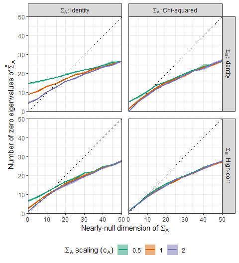

```r
ggsave(
  filename = "../figs/zero-evals.pdf",
  plot     = zero_eval_figs$main,
  device   = "pdf"
)
zero_eval_figs$main
```

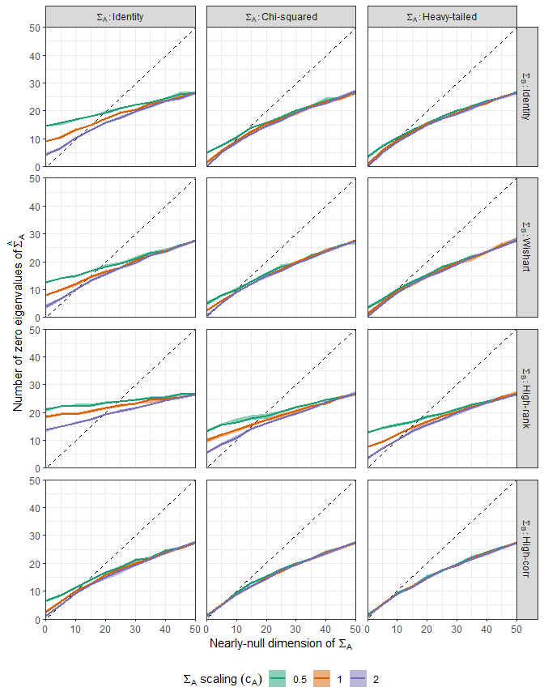

```r
ggsave(
  filename = "../figs/zero-evals-supp.pdf",
  plot     = zero_eval_figs$supp,
  device   = "pdf"
)
zero_eval_figs$supp
```

We repeat the same plot, but now plotting the eigenvalues that are less than 1.

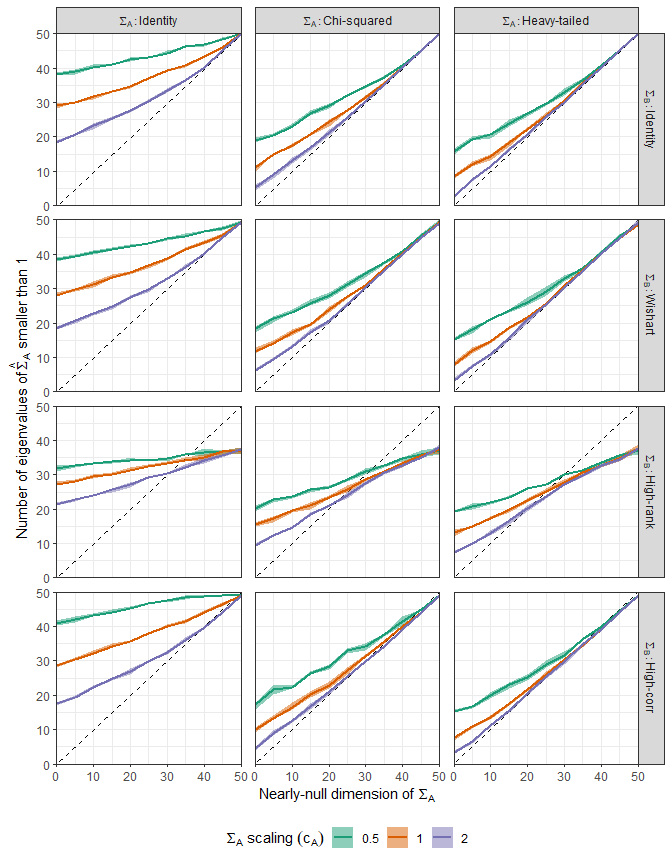

```r
eig_stat_nn %>%
  ggplot(aes(
    x = nearly_null_dim,
    y = nsmall,
    fill = ordered(a_var),
    color = ordered(a_var))) +
  geom_abline(
    slope = 1,
    intercept = 0,
    linetype = "dashed") +
  stat_summary(
    fun.min = function(x) quantile(x, 0.25)[[1]],
    fun.max = function(x) quantile(x, 0.75)[[1]],
    geom = "ribbon",
    color = NA, alpha = 0.5) +
  stat_summary(
    fun = "mean",
    geom = "line",
    size = 1) +
  facet_grid(
    b_type ~ a_type,
    labeller = label_bquote(
      cols = Sigma[A] : .(a_names[a_type]),
      rows = Sigma[B] : .(b_names[b_type])
    )
  ) +
  labs(
    x = expression("Nearly-null dimension of"~Sigma[A]),
    y = expression("Number of eigenvalues of"~hat(Sigma)[A]~"smaller than 1"),
    color = expression(Sigma[A] ~ scaling ~ (c[A])),
    fill = expression(Sigma[A] ~ scaling ~ (c[A]))
  ) +
  coord_cartesian(
    xlim = c(0, 50),
    ylim = c(0, 50),
    expand = FALSE
  ) +
  ## scale_fill_brewer(type = "qual") +
  ## scale_color_brewer(type = "qual") +
  scale_color_manual(values = doc_colours) +
  scale_fill_manual(values = doc_colours) +
  theme(
    legend.position = "bottom",
    panel.spacing = unit(0.75, "lines")
  )
```

```r
ggsave("../figs/small-evals.pdf", device = "pdf")
```

# Figures 7 and 8: Large eigenvalues

We use the same machinery that we developed for the nearly-null space analysis to instead estimate the large eigenvalues of $\Sigma_A$.

```r
p <- 50

I <- 100
J <- 3
K <- 5

E <- diag(p)
mu <- rep(0, p)

n_reps <- 10
nearly_null_dims <- seq(0, p, by=5)
a_vars <- c(0.5, 1, 2)
```

We use a slightly different specification of the between-sires covariance as given in eq. (9)

```r
set_chisquared <- rchisq(p, df=5)/5

a_types_maxeig <- list(
  identity = function(p, d) diag(c(rep(1, p - d), rep(0, d))),
  spike = function(p, d) diag(c(
    rep(5, min(1, p - d)),
    rep(1, max(0, p - d - 1)),
    rep(0, d))),
  chisquared = function(p, d) diag(c(set_chisquared[min(1, p-d):(p-d)], rep(0, d)))
)

a_pop_maxeigs <- list(
  identity = 1,
  spike = 5,
  chisquared = max(set_chisquared),
  heavytail = NA
)
```

```r
p = 50
d = 10

a_eig_df <- sapply(
  a_types_maxeig,
  function(f, ...) diag(f(...)),
  p, d
) %>%
  as.tibble() %>%
  pivot_longer(
    everything(),
    names_to = "structure",
    values_to = "eigenvalue")
```

We re-simulate and re-fit the models on these new parameter values.

```r
eig_ref <- expand_grid(
  rep = 1:n_reps,
  nearly_null_dim = nearly_null_dims,
  a_var = a_vars,
  a_type = names(a_types_maxeig),
  b_type = names(b_types)
) %>%
  mutate(., col_idx = 1:nrow(.))

eig_mat_reml <- matrix(
  nrow = nrow(eig_ref),
  ncol = p
)

eig_mat_manova <- matrix(
  nrow = nrow(eig_ref),
  ncol = p
)

for (idx in 1:nrow(eig_ref)) {

  a_var <- eig_ref[[idx, "a_var"]]
  d <- eig_ref[[idx, "nearly_null_dim"]]

  A <- a_var * a_types_maxeig[[eig_ref[[idx, "a_type"]]]](p, d)
  B <- b_types[[eig_ref[[idx, "b_type"]]]](p)

  df <- rhalfsib(mu, A, I, B, J, E, K)

  reml_est <- stepreml_2way(df)
  eig_mat_reml[eig_ref[[idx, "col_idx"]],] <- eigen(reml_est$S3, symmetric = TRUE, only.values = TRUE)$values

  manova_est <- manova_2way(df)
  eig_mat_manova[eig_ref[[idx, "col_idx"]],] <- eigen(manova_est$S3, symmetric = TRUE, only.values = TRUE)$values
}
```

```r
save(eig_ref, eig_mat_reml, eig_mat_manova, file = "../data/manova-reml.RData")
```

We then compute the differences between the estimated largest eigenvalues of the REML and MANOVA between-sires covariance.

```r
eig_stat_me <- eig_ref %>%
  arrange(col_idx) %>%
  mutate(
    max_manova = apply(eig_mat_manova, 1, max),
    max_reml = apply(eig_mat_reml, 1, max),
    max_diff = max_manova - max_reml,
    a_type  = factor(a_type, levels = names(a_names)),
    b_type  = factor(b_type, levels = names(b_names))
  )

eig_stat_me_sub <- eig_stat_me %>%
  filter(
    (a_type %in% a_sub) & (b_type %in% b_sub)
  )

bias_dfs <- list(
  main = eig_stat_me_sub,
  supp = eig_stat_me
)

bias_figs <- lapply(
  bias_dfs,
  function (df) {
    df %>%
      filter(nearly_null_dim < p) %>%
      ggplot(aes(
        x     = nearly_null_dim,
        y     = max_diff/abs(max_reml),
        fill  = ordered(a_var),
        color = ordered(a_var))) +
      stat_summary(
        fun.min = function(x) quantile(x, 0.25)[[1]],
        fun.max = function(x) quantile(x, 0.75)[[1]],
        geom = "ribbon",
        color = NA, alpha = 0.5) +
      stat_summary(
        fun = "mean",
        geom = "line",
        size = 1) +
      facet_grid(
        b_type ~ a_type,
        labeller = label_bquote(
          cols = Sigma[A] : .(a_names[a_type]),
          rows = Sigma[B] : .(b_names[b_type])
        ),
        scale = "free_y"
      ) +
      labs(
        x = expression("Nearly-null dimension of"~Sigma[A]),
        ## y = expression((lambda[max](hat(Sigma)["A, MANOVA"]) - lambda[max](hat(Sigma)["A, REML"])) /  lambda[max](hat(Sigma)["A, REML"]) ),
        y = expression((hat(lambda)[max]["1, MANOVA"] - hat(lambda)["1, REML"]) /  hat(lambda)["1, REML"]),
        color = expression(Sigma[A] ~ scaling ~ (c[A])),
        fill = expression(Sigma[A] ~ scaling ~ (c[A]))
      ) +
      coord_cartesian(
        xlim = c(0, NA),
        ylim = c(NA, 0),
        expand = FALSE
      ) +
      scale_y_continuous(expand = c(0.05, 0)) +
      ## scale_fill_brewer(type = "qual") +
      ## scale_color_brewer(type = "qual") +
      scale_color_manual(values = doc_colours) +
      scale_fill_manual(values = doc_colours) +
      theme(
        legend.position = "bottom",
        panel.spacing = unit(0.75, "lines")
      )
  }
)

## ggsave("../figs/bias-largest.pdf", device = "pdf")
```

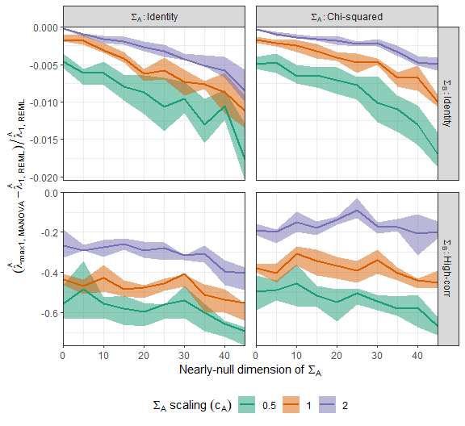

```r
ggsave(
  filename = "../figs/bias-largest.pdf",
  plot     = bias_figs$main,
  device   = "pdf"
)
bias_figs$main
```

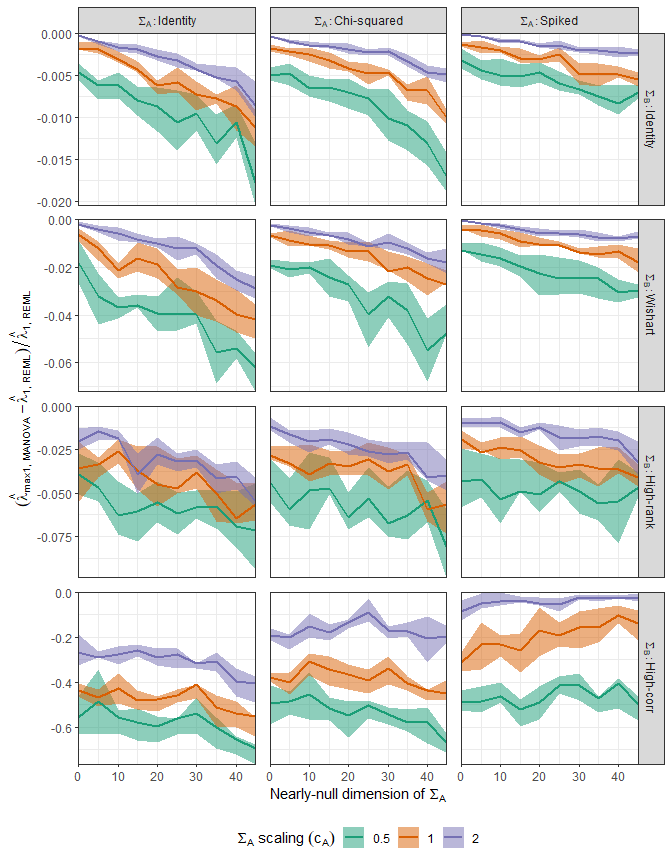

```r
ggsave(
  filename = "../figs/bias-largest-supp.pdf",
  plot     = bias_figs$supp,
  device   = "pdf"
)
bias_figs$supp
```

We repeat the previous plot, but now comparing the largest eigenvalues of the REML eigenvalues with the corresponding population eigenvalues.

```r
eig_stat_me <- eig_stat_me %>%
  mutate(
    a_pop_maxeig = sapply(a_type, function(i) a_pop_maxeigs[[as.character(i)]], USE.NAMES=FALSE),
    reml_maxeig_error = max_reml - a_pop_maxeig
  )

a_sub <- c(a_sub, "chisquared")

eig_stat_me_sub <- eig_stat_me %>%
  filter(
    (a_type %in% a_sub) & (b_type %in% b_sub)
  )

bias_truth_dfs <- list(
  main = eig_stat_me_sub,
  supp = eig_stat_me
)

bias_truth_figs <- lapply(
  bias_truth_dfs,
  function (df) {
    df %>%
      filter(nearly_null_dim < p) %>%
      ggplot(aes(
        x    = nearly_null_dim,
        y    = reml_maxeig_error/a_pop_maxeig,
        fill = ordered(a_var),
        color = ordered(a_var))) +
      stat_summary(
        fun.min = function(x) quantile(x, 0.25)[[1]],
        fun.max = function(x) quantile(x, 0.75)[[1]],
        geom = "ribbon",
        color = NA, alpha = 0.5) +
      stat_summary(
        fun = "mean",
        geom = "line",
        size = 1) +
      ggh4x::facet_grid2(
        b_type ~ a_type,
        labeller = label_bquote(
          cols = Sigma[A] : .(a_names[a_type]),
          rows = Sigma[B] : .(b_names[b_type])
        ),
        scale = "free_y",
        independent = "y"
      ) +
      labs(
        x = expression("Nearly-null dimension of"~Sigma[A]),
        y = expression((hat(lambda)["A, REML"] - lambda[1])/lambda[1]),
        color = expression(Sigma[A] ~ scaling ~ (c[A])),
        fill = expression(Sigma[A] ~ scaling ~ (c[A]))
      ) +
      coord_cartesian(
        xlim = c(0, NA),
        ## ylim = c(0, NA),
        expand = FALSE
      ) +
      scale_y_continuous(expand = c(0.05, 0)) +
      ## scale_fill_brewer(type = "qual") +
      ## scale_color_brewer(type = "qual") +
      scale_color_manual(values = doc_colours) +
      scale_fill_manual(values = doc_colours) +
      theme(
        legend.position = "bottom",
        panel.spacing = unit(0.75, "lines")
      )
  }
)
## ggsave("../figs/bias-to-truth.pdf", device = "pdf")
```

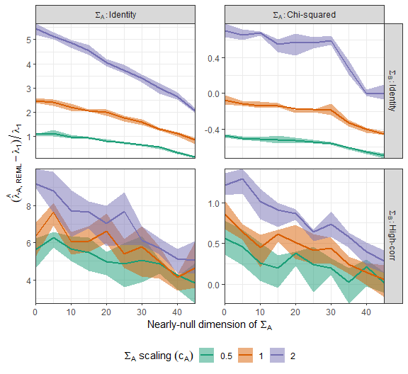

```r
ggsave(
  filename = "../figs/bias-to-truth.pdf",
  plot     = bias_truth_figs$main,
  device   = "pdf"
)
bias_truth_figs$main
```

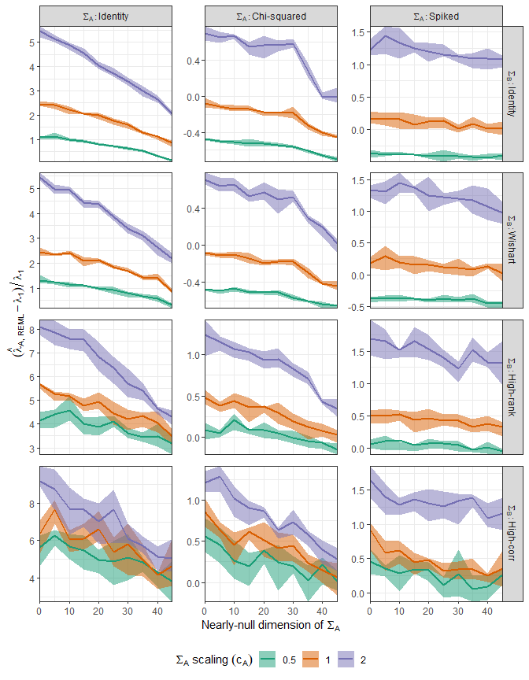

```r
ggsave(
  filename = "../figs/bias-to-truth-supp.pdf",
  plot     = bias_truth_figs$supp,
  device   = "pdf"
)
bias_truth_figs$supp
```